# Sample Notebook - Multiple Regression: Estimation

# Using our results for predictions

Going back to the functional form of model 3:

$ln(price_i) = \beta_0 + \beta_1 ln(lotsize_i) + \beta_2 bedrooms_i + \beta_3 bathrooms_i + e_i$,

after we estimate it and assuming that the expected values of the error term in that equation is zero, we get $\hat{y_i}$, the predicted value of the expectation of $y_i$ given the $x_i$, where $\hat{\beta_0}$, $\hat{\beta_1}$, $\hat{\beta_2}$, and $\hat{\beta_3}$ are the least squares estimates of our regression parameters:

$\hat{y_i} = \hat{\beta_0} + \hat{\beta_1} ln(lotsize_i) + \hat{\beta_2} bedrooms_i + \hat{\beta_3} bathrooms_i$

The predicted value $\hat{y_i}$ is a random variable because it depends on our sample, so we can calculate a confidence interval and test hypotheses about it (as long as we can determine its distribution and variance). The prediction has a normal distribution, since it’s a combination of normally distributed random variables (our regression estimators).

However, the variance of the prediction is larger than the variance of $\hat{y_i}$. That’s because $\hat{y_i}$ is $E(y|x)$, so its variance is the variance of the predicted $E(y|x)$. Not surprisingly, the variance of the forecast of a particular occurrence of $y$ has a larger variance!

To make our lives easier, let’s compare the variances from a simple linear regression instead of a multiple linear regression. The same principles would apply in the multiple linear regression case, but we’ll let R do the heavy lifting there!

Let’s say this is our regression that we’re estimating:

$y_i = \beta_0 + \beta_1 x_i + e_i$.

We then get our estimator $\hat{\beta_1}$ that is normally distributed:

$\hat{\beta_1} \sim \mathcal{N}(\beta, \frac{\sigma^2}{\Sigma(x_i-\bar{x})^2})$

Of course, we need an estimator for $\sigma^2$, because we don’t know the theoretical distribution $\sigma^2$. We can replace the theoretical value $\sigma^2$ with the estimator:

$\hat{\sigma^2} = \frac{\Sigma \hat{e_i}^2}{N-2}$,

which is a $t$ distribution with $N-2$ degrees of freedom.

The confidence interval is then given by $\hat{\beta_1} \pm t_c \cdot SE(\hat{\beta_1})$.

For the predicted value (or forecast value–I’ll use $f_i$ since $p$ already means a bunch of stuff), we also need to use an estimated variance and we’ll again use a $t$ distribution.

The main difference here is that the following equation applies to any given $x$, not only to those values that are in the dataset:

$\widehat{var(f_i)} = \hat{\sigma^2}[1 + \frac{1}{N} + \frac{(x_i - \bar{x})^2}{\Sigma_{j=1}^N(x_j-\bar{x})^2}]$

We can reduce this to:

$\widehat{var(f_i)} = \hat{\sigma^2} + \frac{\hat{\sigma^2}}{N} + (x_i - \bar{x})^2 Var(\hat{\beta_1})$.

As you can see, this is larger than the variance of $\hat{\beta_1}$ on its own!

So let’s use the `predict()` function in R to build out both confidence intervals and prediction intervals. We’ll then plot them to illustrate that, because of the larger variance, the prediction intervals are wider than the confidence intervals.

```r
x1min <- min(Housing$llotsize)
x1max <- max(Housing$llotsize)
llotsize <- seq(from = x1min, to = x1max, length.out = 6)
x2min <- min(Housing$bedrooms)
x2max <- max(Housing$bedrooms)
bedrooms <- seq(from = x2min, to = x2max, length.out = 6)
x3min <- min(Housing$bathrms)
x3max <- max(Housing$bathrms)
bathrms <- seq(from = x3min, to = x3max, length.out = 6)
newdata <- data.frame(llotsize, bedrooms, bathrms)


yconfidence <- predict(mod3, newdata = newdata, interval = 'confidence')

yforecast <- predict(mod3, newdata = newdata, interval = 'predict')
```

```r
df <- data.frame(yconfidence[,1], yconfidence[,2], yconfidence[,3], yforecast[,2], yforecast[,3])
colnames(df) <- c('fit', 'lwr_confint', 'upr_confint', 'lwr_forecast', 'upr_forecast')
```

```r
colors <- c('fit' = 'darkred', 'lwr_confint' = 'steelblue', 'upr_confint' = 'steelblue', 'lwr_forecast' = 'darkgreen', 'upr_forecast' = 'darkgreen')
```

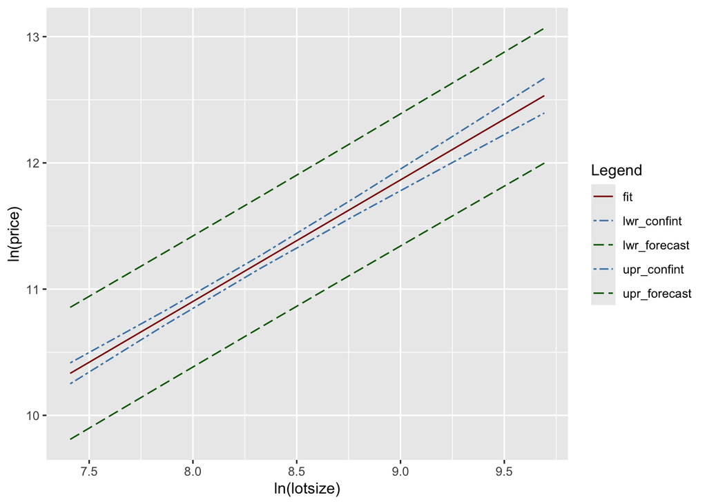

```r
ggplot(df, aes(x = llotsize)) +
    geom_line(aes(y = fit, color = 'fit')) +
    geom_line(aes(y = lwr_confint, color = 'lwr_confint'), linetype = 'twodash') +
    geom_line(aes(y = upr_confint, color = 'upr_confint'), linetype = 'twodash') +
    geom_line(aes(y = lwr_forecast, color = 'lwr_forecast'), linetype = 'longdash') +
    geom_line(aes(y = upr_forecast, color = 'upr_forecast'), linetype = 'longdash') +
    labs(x = 'ln(lotsize)',
         y = 'ln(price)',
         color = 'Legend') +
  scale_color_manual(values = colors)
```

As you can see above, the wider intervals belong to the foreast intervals, due to the larger variance.

# Goodness-of-Fit

First, some definitions.

- **SST**: Total Sum of Squares. This is the sum of squared differences between each observed dependent variable and the mean of that variable. You may also see this written as **TSS**.

The formula is:

$SST = \Sigma_{i=1}^n(y_i - \bar{y})^2$.

$y_i$ is the value of the observed $y$ for each of the $n$ data points, and $\bar{y}$ is the mean value of the observed data points.

- **SSR**: Regression Sum of Squares. This is the sum of squared differences between each value of the dependent variable predicted by a regression model for each data point of the independent variable, and the mean of the observed dependent variable. You may also see this referred to as the explained sum of squares (ESS).

The sum of squares regression shows the portion of total variability in $y$ explained by the regression model.

The formula is:

$SSR = \Sigma_{i=1}^n (\hat{y_i} - \bar{y})^2$.

$\hat{y_i}$ are the values predicted by the regression nmodel for each of the $n$ data points, and $\bar{y}$ is the mean value for $y$.

- **SSE**: Error Sum of Squares. This is the sum of the squared difference between each value of the observed dependent variable and the value of the dependent variable as predicted by a regression model. It measure the difference between actual and prediction.

This is also called the residual sum of squares (I will often use this term), and the unexplained sum of squares.

This represents the unexplained variability, the portion of the total variability that can’t be explained by the regression model.

The formula is:

$SSE = \Sigma_{i = 1}^n(y_i - \hat{y_i})^2$.

When we think about the *total* variation of $y$ around its sample mean (the *SST*), this can be decomposed into the explained and the unexplained parts (the *SSR* and the *SSE*, respectively). We can write this as:

$SST = SSR + SSE$.

The coefficient of determination, the $R^2$, is defined as the proportion of the total variance in $y$ that is explained by the regression.

If you divide both sides of the above equation by *SST* and rearrange, you get the following formula to calculate the $R^2$:

$R^2 = \frac{SSR}{SST} = 1-\frac{SSE}{SST}$.

We can take advantage of the “1 minus” bit because it’s a *proportion*, so the $R^2$ takes values between 0 and 1. The closer to 1, the closer the fit of the regression line to the data and the higher the proportion of the total variability of $y$ the regression explained.

Let’s take a quick look back at one of our models and pull the $R^2$:

```r
summary(mod3)$r.squared
```

```
## [1] 0.5037511
```

If you also need the SSE or the SSR, you can use `anova`:

```r
anov <- anova(mod3)
anov_df <- data.frame(anov)


kbl(
  anov_df,
  caption = "Output generated by ANOVA",
  align = "lcc"
) |>
  kable_classic(full_width = FALSE) |>
  row_spec(0, bold = TRUE)
```

Output generated by ANOVA

|  | Df | Sum.Sq | Mean.Sq | F.value | Pr..F. |
| --- | --- | --- | --- | --- | --- |
| llotsize | 1 | 25.367732 | 25.3677320 | 367.39578 | 0 |
| bedrooms | 1 | 6.162883 | 6.1628833 | 89.25580 | 0 |
| bathrms | 1 | 6.458851 | 6.4588510 | 93.54224 | 0 |
| Residuals | 542 | 37.423703 | 0.0690474 | NA | NA |

The error sum of squares, *SSE*, is in the final row, second column of the table above ($SSE =$ `anov[4,2]`). The regression sum of squres, *SSR*, can be found by summing up the rows in column two for each coefficient–each coefficient has its own sum of squares due to regression, and their sum equals the total *SSR*. To find the total sum of squares, *SST*, you sum up all of the rows in column 2.

There are other useful items in this table. In the final row and third column, you can also find the estimated variance $\hat{\sigma^2}$. The degrees of freedom is also in the first column.

Back to column 2, we see that lotsize has the largest contribution to the reduction of variability in the residuals. Let’s find the proportion of *SSR* explained by *llotsize*:

```r
cat('The SST is', sum(anov_df$Sum.Sq), '\n')
```

```
## The SST is 75.41317
```

```r
cat('The proportion of SSR explained by lot size is',  anov_df[1,2]/(anov_df[1,2] + anov_df[2,2] + anov_df[2,3]), '\n')
```

```
## The proportion of SSR explained by lot size is 0.6730002
```

```r
cat('The R squared of the regression is', (anov_df[1,2] + anov_df[2,2] + anov_df[2,3])/sum(anov_df$Sum.Sq))
```

[output not shown]

We see that a majority of the regression sum of squares is explained by the effect of *lotsize*. This can be a very useful thing to consider when looking at model selection, a topic we will return to in future.

We can also compare the fits of some of our models:

```r
mk_fit(
  `Model 1: ln(price) ~ ln(lot size)` = mod1,
  `Model 2: ln(price) ~ ln(lot size) + ln(lot size)^2 + bedrooms` = mod2,
  `Model 3: ln(price) ~ ln(lot size) + bedrooms + bathrooms` = mod3,
  caption = "Model fit comparison"
)
```

Model fit comparison

| Model | R² | Adj. R² | AIC | BIC | Residual SE |
| --- | --- | --- | --- | --- | --- |
| Model 1: ln(price) ~ ln(lot size) | 0.336 | 0.335 | 250.7 | 263.6 | 0.303 |
| Model 2: ln(price) ~ ln(lot size) + ln(lot size)^2 + bedrooms | 0.421 | 0.417 | 180.7 | 202.2 | 0.284 |
| Model 3: ln(price) ~ ln(lot size) + bedrooms + bathrooms | 0.504 | 0.501 | 96.0 | 117.5 | 0.263 |

We see that the $R^2$ is high on both multiple models than the simple model, and higher for model three than model two. We will discuss the AIC and BIC in more detail later!